# R Notebook

# Aufgabe 9: Pearson Chi-Quadrat-Test | Cramers V

## Tragen Männer oder Frauen mehr Brille?

### Daten

Variable1: Brille Varibale2: Geschlecht

## Aufgabenstellung:

Tragen Männer oder Frauen mehr Brille?

## 1. Hypothese:

H0: Es gibt keinen Zusammmenhang zwischen dem Geschlecht und den Tragen Brille.

## 2. Voraussetzungen:

Die Variablen sind kategorial (nominal- oder ordinalskaliert)

### 2.1. Datensatz:

```r
library(readxl)
chi <- read_xlsx("uebung9.xlsx")
chi
```

| ID | Geschlecht | Brille |
| --- | --- | --- |
| 1 | w | ja |
| 2 | w | ja |
| 3 | w | ja |
| 4 | w | ja |
| 5 | w | ja |
| 6 | w | ja |
| 7 | w | ja |
| 8 | w | ja |
| 9 | w | ja |
| 10 | w | ja |

[output cut: 190 more lines]

## 3. Balkendiagramm:

```r
counts <- table(chi$Geschlecht, by = chi$Brille)

counts
```

```
   by
    ja nein
  m 70   40
  w 30   60
```

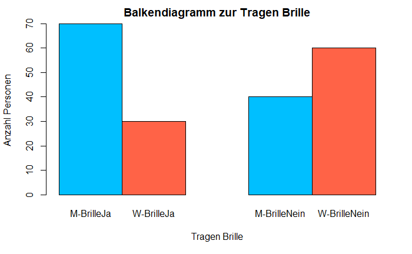

```r
barplot(counts, main="Balkendiagramm zur Tragen Brille", col=c("deepskyblue","tomato"),
        ylab="Anzahl Personen", xlab = "Tragen Brille", beside=T,
        names.arg =c("M-BrilleJa", "W-BrilleJa", "M-BrilleNein", "W-BrilleNein"))
```

## 4. Kreuztabelle:

```r
counts<- table(Geschlecht = chi$Geschlecht, Brille = chi$Brille)
print("beobachtete Werte ")
```

```
[1] "beobachtete Werte "
```

```r
print(counts)
```

```
          Brille
Geschlecht ja nein
         m 70   40
         w 30   60
```

Die Tabelle wurde angelegt.

## 5. Erwarteten Werte:

```r
ch <- chisq.test(counts, correct = F)
print("Erwartete Werte ")
```

```
[1] "Erwartete Werte "
```

```r
ch
```

```
    Pearson's Chi-squared test

data:  counts
X-squared = 18.182, df = 1, p-value = 2.008e-05
```

```r
round(ch$expected, 2)
```

```
          Brille
Geschlecht ja nein
         m 55   55
         w 45   45
```

Die beobachteten und die erwarteten Werte wurden verglichen. Es zeigen sich für das Beispiel einen Unterschiede. Ob es jedoch signifikant sind, wird mittels Chi-Quadrat-Test geprüft.

## 6. X² :

### Fall 2 : (n > 50 und df = 1 und die erwarteten Zellhäufigkeiten sind > 5)

**Anpassung: Korrektur nach Yates**

$$\chi^2 = \sum^I_{i=1}\sum^J_{j=1}\frac{(\Bigl| f_{ij}-f^{'}_{ij}\Bigl| -0.5)^2}{f^{'}_{ij}}$$

```r
ch <- chisq.test(counts, correct = TRUE) # Die Anpassung nach Yates - correct = TRUE - Die Formel wird um -0.5 erweietert
ch
```

```
    Pearson's Chi-squared test with Yates' continuity correction

data:  counts
X-squared = 16.99, df = 1, p-value = 3.758e-05
```

**Bericht:**(Chi-Quadrat(1) = 16.99, p = 3.758e-05)

```r
sprintf("kritischer Prüfwert: %.2f",qchisq(0.95, df=1))
```

```
[1] "kritischer Prüfwert: 3.84"
```

**Hinweis:**
$$kritische \thinspace Prüfwert < empirsche \thinspace Prüfwert \rightarrow sig. \\ 3.84 < 16.99 \rightarrow sig$$

Es zeigt sich, dass ein sig. Ergebnis vorliegt (Chi-Quadrat(1) = 16.99, p = 3.758e-05, n = 200). Damit gibt es einen Zusammenhang zwischen dem Geschlecht und dem Tragen einer Brille.

## 7. Cramers ´V:

$$\mbox{Cramers V} = \sqrt{\frac{\chi^2}{n(2-1)}} = \sqrt{\frac{16.989899}{200 (2-1)}}$$

```r
anzahl <- nrow(chi)

sprintf("Der Datensatz hat %d Zeilen.",anzahl)
```

```
[1] "Der Datensatz hat 200 Zeilen."
```

```r
sprintf("Das Chi-Quadrat liegt bei %.2f.",ch$statistic)
```

```
[1] "Das Chi-Quadrat liegt bei 16.99."
```

```r
cramersV <- sqrt(( ch$statistic)/(anzahl*(2-1)))
sprintf("Die Effektstärke liegt bei %.2f.",cramersV)
```

```
[1] "Die Effektstärke liegt bei 0.29."
```

Cramer s V ist immer positiv -> keine Aussage über die Richtung des Zusammenhangs

$$\begin{align}
\text{Schwacher Effekt: } 0.1 &< ||Cramers V|| \leq 0.3 \\
\text{Schwacher bis mittlerer Effekt: }0.3 &< ||Cramers V|| \leq 0.4 \\
\text{Mittlerer Effekt: } 0.4 &< ||Cramers V|| < 0.5 \\
\text{Mittlerer bis starker Effekt: }0.5 &= ||Cramers V|| \\
\text{Starker Effekt: } 0.5 &< ||Cramers V||
\end{align}$$

Es zeigt sich für unsere Auswertung, dass ein schwacher Zusammenhang besteht.

## 8. Aussage:

Der Geschlecht und das Tragen Brille stehen in einem Zusammenhang (Chi-Quadrat(1) = 16.99, p = .000, n= 200). Der Zusammenhang ist schwachstark (Cramers V = .29). Damit kann die H0 verworfen werden.